# 02_production-checkpoint

```python
#hide
!pip install -Uqq fastbook
import fastbook
fastbook.setup_book()
```

```python
#hide
from fastbook import *
from fastai.vision.widgets import *
```

```python
key = '44cf29bdfbb6446e9ab621e4a2fd9302'
```

```python
#hide
ims = ['http://3.bp.blogspot.com/-S1scRCkI3vY/UHzV2kucsPI/AAAAAAAAA-k/YQ5UzHEm9Ss/s1600/Grizzly%2BBear%2BWildlife.jpg']
```

```python
dicter={
    'dfdf':'fdfdf'
}
```

```python
bird_types = {
    'Dendrocygna autumnalis':'Black-bellied whistling-duck',
    'Dendrocygna bicolor':'Fulvous whistling-duck',
    'Anser caerulescens':'Snow goose',
    'Anser rossii':'Ross\'s goose',
    'Anser albifrons':'Greater white-fronted goose',
    'Anser brachyrhynchus':'Pink-footed goose',
    'Branta bernicla':'Brant',
    'Branta leucopsis':'Barnacle goose',
    'Branta hutchinsii':'Cackling goose',
    'Branta canadensis':'Canada goose, Branta canadensis',
    'Cygnus olor':'Mute swan',
    'Cygnus buccinator':'Trumpeter swan',
    'Cygnus columbianus':'Tundra swan',
    'Aix sponsa':'Wood duck',
    'Spatula querquedula':'Garganey',
    'Spatula discors':'Blue-winged teal',
    'Spatula cyanoptera':'Cinnamon teal',
    'Spatula clypeata':'Northern shoveler',
    'Mareca strepera':'Gadwall',
    'Mareca penelope':'Eurasian wigeon',
    'Mareca americana':'American wigeon',
    'Anas platyrhynchos':'Mallard',
    'Anas rubripes':'American black duck',
    'Anas fulvigula':'Mottled duck',
    'Anas bahamensis':'Northern pintail',
    'Anas crecca':'Green-winged teal',
    'Aythya valisineria':'Canvasback',
    'Aythya americana':'Redhead',
    'Aythya collaris':'Ring-necked duck',
    'Aythya fuligula':'Tufted duck',
    'Aythya marila':'Greater scaup',
    'Aythya affinis':'Lesser scaup',
    'Somateria spectabilis':'King eider',
    'Somateria mollissima':'Common eider',
    'Histrionicus histrionicus':'Harlequin duck',
    'Melanitta perspicillata':'Surf scoter',
    'Melanitta deglandi':'White-winged scoter',
    'Melanitta americana':'Black scoter',
    'Clangula hyemalis':'Long-tailed duck',
    'Bucephala albeola':'Bufflehead',
    'Bucephala clangula':'Common goldeneye',
    'Bucephala islandica':'Barrow\'s goldeneye',
    'Mergellus albellus':'Smew',
    'Lophodytes cucullatus':'Hooded merganser',
    'Mergus merganser':'Common merganser',
    'Mergus serrator':'Red-breasted merganser',
    'Oxyura jamaicensis':'Ruddy duck',
}
```

```python
path = Path('birds')
```

```python
for o in bird_types:
    dest = (path/o)
    dest.mkdir(exist_ok=True)
    results = search_images_bing(key, f'{o}')
    download_images(dest, urls=results.attrgot('contentUrl'))
```

```python
if not path.exists():
    path.mkdir()
    for o in bird_types:
        dest = (path/o)
        dest.mkdir(exist_ok=True)
        results = search_images_bing(key, f'{o}')
        download_images(dest, urls=results.attrgot('contentUrl'))
```

```python
fns = get_image_files(path)
fns
```

[output not shown]

```python
failed = verify_images(fns)
failed
```

[output not shown]

```python
failed.map(Path.unlink);
```

### Sidebar: Getting Help in Jupyter Notebooks

## From Data to DataLoaders

```python
??aug_transforms
```

```python
birds = DataBlock(
    blocks=(ImageBlock, CategoryBlock),
    get_items=get_image_files,
    splitter=RandomSplitter(valid_pct=0.2),
    get_y=parent_label,
    item_tfms=Resize(460),
    batch_tfms=aug_transforms(size=224, min_scale=0.75))
```

```python
dls = birds.dataloaders(path)
```

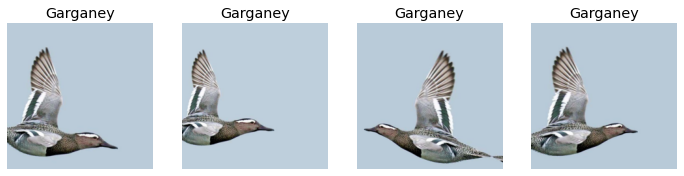

```python
dls.train.show_batch(max_n=4, nrows=1, unique=True)
```

## Training Your Model, and Using It to Clean Your Data

```python
learn = cnn_learner(dls, resnet34, metrics=error_rate)
learn.fine_tune(8)
```

| epoch | train_loss | valid_loss | error_rate | time |
| --- | --- | --- | --- | --- |
| 0 | 3.421931 | 1.698349 | 0.454815 | 01:27 |

| epoch | train_loss | valid_loss | error_rate | time |
| --- | --- | --- | --- | --- |
| 0 | 1.769248 | 1.322846 | 0.348148 | 01:51 |
| 1 | 1.400859 | 1.239486 | 0.329630 | 01:51 |
| 2 | 1.162845 | 1.158395 | 0.299259 | 01:53 |
| 3 | 0.885311 | 1.080245 | 0.274074 | 01:51 |
| 4 | 0.728701 | 1.039519 | 0.268148 | 01:52 |
| 5 | 0.537871 | 1.033533 | 0.250370 | 01:51 |
| 6 | 0.436177 | 1.014955 | 0.251852 | 01:52 |
| 7 | 0.375648 | 1.023010 | 0.251852 | 01:51 |

[output not shown]

[output cut: 23 more lines]

[output not shown]

[figure not shown]

```python
interp = ClassificationInterpretation.from_learner(learn)
interp.plot_confusion_matrix()
```

[figure not shown]

```python
interp.plot_top_losses(5, nrows=1)
```

```python
cleaner = ImageClassifierCleaner(learn)
cleaner
```

```python
#hide
for idx in cleaner.delete(): cleaner.fns[idx].unlink()
for idx,cat in cleaner.change(): shutil.move(str(cleaner.fns[idx]), path/cat)
```

## Turning Your Model into an Online Application

### Using the Model for Inference

```python
learn.export()
```

```python
path = Path()
path.ls(file_exts='.pkl')
```

```
(#1) [Path('export.pkl')]
```

```python
learn_inf = load_learner(path/'export.pkl')
```

```python
learn_inf.predict('images/grizzly.jpg')
```

[output not shown]

```python
learn_inf.dls.vocab
```

[output not shown]

### Creating a Notebook App from the Model

```python
btn_upload = widgets.FileUpload()
btn_upload
```

```python
#hide
# For the book, we can't actually click an upload button, so we fake it
btn_upload = SimpleNamespace(data = ['images/grizzly.jpg'])
```

```python
img = PILImage.create(btn_upload.data[-1])
```

```python
out_pl = widgets.Output()
out_pl.clear_output()
with out_pl: display(img.to_thumb(128,128))
out_pl
```

```python
pred,pred_idx,probs = learn_inf.predict(img)
```

```python
lbl_pred = widgets.Label()
lbl_pred.value = f'Prediction: {pred}; Probability: {probs[pred_idx]:.04f}'
lbl_pred
```

```python
btn_run = widgets.Button(description='Classify')
btn_run
```

```python
def on_click_classify(change):
    img = PILImage.create(btn_upload.data[-1])
    out_pl.clear_output()
    with out_pl: display(img.to_thumb(128,128))
    pred,pred_idx,probs = learn_inf.predict(img)
    lbl_pred.value = f'Prediction: {pred}; Probability: {probs[pred_idx]:.04f}'

btn_run.on_click(on_click_classify)
```

```python
#hide
#Putting back btn_upload to a widget for next cell
btn_upload = widgets.FileUpload()
```

```python
VBox([widgets.Label('Select your bird!'),
      btn_upload, btn_run, out_pl, lbl_pred])
```

### Turning Your Notebook into a Real App

```python
#hide
!pip install voila
!jupyter serverextension enable voila
```

```
Enabling: voila
- Writing config: /root/.jupyter
    - Validating...
      voila 0.1.22 OK
```

## How to Avoid Disaster

### Unforeseen Consequences and Feedback Loops

## Questionnaire

1. Provide an example of where the bear classification model might work poorly in production, due to structural or style differences in the training data.
2. Where do text models currently have a major deficiency?
3. What are possible negative societal implications of text generation models?
4. In situations where a model might make mistakes, and those mistakes could be harmful, what is a good alternative to automating a process?
5. What kind of tabular data is deep learning particularly good at?
6. What's a key downside of directly using a deep learning model for recommendation systems?
7. What are the steps of the Drivetrain Approach?
8. How do the steps of the Drivetrain Approach map to a recommendation system?
9. Create an image recognition model using data you curate, and deploy it on the web.
10. What is `DataLoaders`?
11. What four things do we need to tell fastai to create `DataLoaders`?
12. What does the `splitter` parameter to `DataBlock` do?
13. How do we ensure a random split always gives the same validation set?
14. What letters are often used to signify the independent and dependent variables?
15. What's the difference between the crop, pad, and squish resize approaches? When might you choose one over the others?
16. What is data augmentation? Why is it needed?
17. What is the difference between `item_tfms` and `batch_tfms`?
18. What is a confusion matrix?
19. What does `export` save?
20. What is it called when we use a model for getting predictions, instead of training?
21. What are IPython widgets?
22. When might you want to use CPU for deployment? When might GPU be better?
23. What are the downsides of deploying your app to a server, instead of to a client (or edge) device such as a phone or PC?
24. What are three examples of problems that could occur when rolling out a bear warning system in practice?
25. What is "out-of-domain data"?
26. What is "domain shift"?
27. What are the three steps in the deployment process?

### Further Research

1. Consider how the Drivetrain Approach maps to a project or problem you're interested in.
2. When might it be best to avoid certain types of data augmentation?
3. For a project you're interested in applying deep learning to, consider the thought experiment "What would happen if it went really, really well?"
4. Start a blog, and write your first blog post. For instance, write about what you think deep learning might be useful for in a domain you're interested in.